# Tema 10: Problemas de Especificación

Jorge Sosa-García

Primavera 2023

## 10.1. Modelos con Error de Especificación

Ahora hablemos de las consecuencias de violaciones al supuesto RLM1. En particular del **error de especificación** que ocurre cuando el modelo propuesto no refleja adecuadamente la relación entre las variables explicativas y la variable dependiente.

Aunque el error de especificación tiene consecuencias graves para los estimadores de MCO de los parámetros poblacionales (pues que sean BLUE depende de que se satisfaga RLM1), es hasta cierto punto un problema menor si se tiene acceso a información de todas las variables necesarias para describir adecuadamente la relación funcional que se quiere estimar.

De hecho, ya contamos con una gran herramienta para detectar formas funcionales con error: la prueba $F$. Esta prueba nos puede ayudar a identificar si es que *sobran variables explicativas* en el modelo (o si faltan términos cuadráticos de las variables que ya se están incluyendo).

Sin embargo, la prueba $F$ no nos ayuda a identificar si una variable incluida debería estar en una forma funcional distinta (como en logaritmo, por ejemplo). Para identificar estas relaciones no lineales específicas necesitamos una prueba más poderosa.

### 10.1.1. Prueba RESET

Para detectar errores de especificación más generales (como los de forma funcional de una variable explicativa) usaremos la prueba conocida como **RESET** (Regression Equation Specification Error Test).

La idea que da lugar a la prueba RESET es muy sencilla. Suponga que se tiene un modelo que satisface los supuestos RLM2 a RLM4:
$$y = \beta_0 + \beta_1 x_1 + ... + \beta_k x_k + u
\quad\quad\quad\quad\quad\quad\quad\quad\quad\quad\quad (1)$$
Si el modelo está adecuadamente especificado (es decir, si cumple con RLM1), entonces incorporar funciones no lineales (polinómicas) de las variables explicativas debería resultar en que estos términos no son significativos.

Hacer esto nos ayuda a detectar algunos problemas de formas funcionales, pero tiene la desventaja de que *puede usar muchos grados de libertad de la prueba* $F$.

Para implementar la prueba RESET, en lugar de incorporar términos polinómicos de las variables explicativos, en el modelo se añaden los términos cuadráticos y cúbicos de los valores ajustados:
$$y = \beta_0 + \beta_1 x_1 + ... + \beta_k x_k +
\delta_1 \hat{y}^2 + \delta_2 \hat{y}_3 + v \quad\quad\quad\quad\quad
(2)$$
De la ecuación (2) **no nos interesan los resultados obtenidos**, sino que simplemente es una *regresión auxiliar* que nos ayudará a explorar la hipótesis de que al modelo (1) le falta considerar términos polinomiales de sus variables explicativas.

De esta manera, la prueba RESET consiste en una simple prueba de hipótesis:
$$\begin{align*}
H_0: &\: \text{El modelo (1) está bien especificado} \\
H_1: &\: H_0 \text{ no es correcto}
\end{align*}$$

En términos de la regresión auxiliar (2), la prueba RESET es simplemente el estadístico $F$ de la siguiente prueba:
$$\begin{align*}
H_0: &\: \delta_1 = \delta_2 = 0
\quad\quad\quad\quad\quad\quad\quad\quad\quad\quad \\
H_1: &\: H_0 \text{ no es correcto}
\end{align*}$$

### 10.1.2. Pruebas para Modelos no Anidados

Para explorar otros errores de especificación necesitamos pruebas un poco más complejos. Suponga que queremos comparar los siguientes dos modelos:
$$\begin{align*}
y &= \beta_0 + \beta_1 \: x_1 + \beta_2 \: x_2 + u
\quad\quad\quad\quad\quad\quad\quad (3)\\
y &= \beta_0 + \beta_1 \ln(x_1) + \beta_2 \ln(x_2) + u
\quad\quad\quad\quad (4)
\end{align*}$$
para identificar si las variables explicativas deben ir en su forma de nivel o de logaritmo.

Notemos que para hacer esta comparación no podemos simplemente recurrir a un estadístico $F$ pues no se trata de *modelo anidados* (donde uno es una caso particular del otro).

Para poder elegir entre los modelos (3) y (4) se han propuesto dos enfoques. El primero es construir un modelo que incluya ambas ecuaciones como casos particulares:
$$y = \gamma_0 +
\gamma_1 x_1 + \gamma_2 x_2 + \gamma_3 \ln(x_1) + \gamma_4 \ln(x_2) +
u$$
Con este modelo se puede hacer la prueba de hipótesis para capturar cual forma funcional es la correcta.

Por ejemplo la prueba $F$
$$\begin{align*}
H_0: &\: \gamma_3 = \gamma_4 = 0\\
H_1: &\: H_0 \text{ no es correcto}
\end{align*}$$
se usaría para la hipótesis de que las variables $x_1$ y $x_2$ deben ir en su versión de nivel.

De manera análoga, la prueba $F$
$$\begin{align*}
H_0: &\: \gamma_1 = \gamma_2 = 0\\
H_1: &\: H_0 \text{ no es correcto}
\end{align*}$$
se usaría para la hipótesis de que las variables $x_1$ y $x_2$ deben ir en su versión de logaritmo.

El segundo enfoque, conocido como la prueba **Davidson-MacKinnon** (DM), se basa en el principio de que si la ecuación (3) es correcta, entonces incorporar las variables en su versión de logaritmo no debería ser significante. De manera análoga, si creemos que la ecuación (4) es la correcta, entonces incorporar los regresores en su versión de nivel no debería resultar significativo.

De esta manera, si suponemos que el modelo (3) es correcto, la prueba DM propone:

1. Estimar el modelo (4) y recuperar sus valores ajustados, $\hat{\hat{y}}$.
2. Estimar el modelo (3) incorporando $\hat{\hat{y}}$ como variable explicativa:
   $$y = \beta_0 + \beta_1 x_1 + \beta_2 x_2 +
   \theta \hat{\hat{y}} + v$$
3. Realizar una prueba $t$ (de dos colas) para la significancia estadística de $\theta$, donde
4. Un estadístico $t$ significativo es evidencia de que el modelo (3) (que creíamos correcto) está mal especificado.

Una prueba análoga se puede realizar si suponemos que el modelo (4) es el que está bien especificado.

Notemos que en ambos enfoques es posible que las pruebas no revelen un modelo ganador (ambos modelos pueden rechazarse o ninguno puede ser rechazado). Más aún, rechazar un modelo no significa que la alternativa propuesta sea la correcta.

## 10.2. Variables Proxy

Un problema más grave es cuando, por falta de disponibilidad, se omite una variable relevante del modelo que se desea estimar. Esto, como se discutió anteriormente, resulta en sesgo de variable omitida.

Una posibilidad para resolver, o al menos mitigar, este problema es el uso de una **variable proxy**.

Consideremos el modelo
$$y = \beta_0 +
\beta_1 x_1 + \beta_2 x_2 + \beta_3 x_3^* + u$$
Supongamos que tenemos información sobre las variables $x_1$ y $x_2$ pero para la variable $x_3^*$ solo tenemos una variable proxy que denotamos por $x_3$. ¿Cuándo podemos usar $x_3$ para obtener estimadores insesgados de $\beta_1$ y $\beta_2$?

Para obtener estos estimadores insesgados, primero debemos verificar que $x_3$ se un *buen proxy* de $x_3^*$. Esto se cumple si las dos variables están relacionadas:
$$x_3^* =
\delta_0 + \delta_3 x_3 + v_3$$

De esta manera, se puede estimar la regresión de $y$ en $x_1, x_2$ y $x_3$ y se obtienen estimadores insesgados de $\beta_1$ y $\beta_2$ si se cumplen los siguientes supuestos:

1. El término de error $u$ no está correlacionado con $x_1, x_2$ y $x_3^*$. Es decir, si el modelo poblacional satisface RLM3.  
   Además, $x_3$ tampoco debe estar correlacianada con $u$.
2. El término de error $v_3$ no está correlacionado con $x_1, x_2$ y $x_3$.
   Esto quiere decir que $x_3$ es un buen proxy de $x_3^*$. En términos matemáticos
   $$\mathrm{E}[x_3^* | x_1, x_2,
   x_3] = \mathrm{E}[x_3^* | x_3] = \delta_0 + \delta_3 x_3$$
   lo que señala que, una vez que se controla por el proxy $x_3$, las variables explicativas $x_1$ y $x_2$ no tienen efecto (en valor esperado) sobre $x_3^*$

El porque estos supuestos son necesarios es fácil de ver. Recordemos que:
$$\begin{align*}
y &= \beta_0 + \beta_1 x_1 + \beta_2 x_2 + \beta_3 x_3^* + u \\
&= \beta_0 + \beta_1 x_1 + \beta_2 x_2 + \beta_3 [\delta_0 +
\delta_3 x_3 + v_3] \\
&= (\beta_0 + \beta_3 \delta_0) + \beta_1 x_1 + \beta_2 x_2 +
\beta_3 \delta_3 x_3 + (u + \beta_3 v_3) \\
&= \alpha_0 + \beta_1 x_1 + \beta_2 x_2 + \alpha_3 x_3 + e
\end{align*}$$
donde $\alpha_0 = \beta_0 + \beta_3 \delta_0$, $\alpha_3 = \beta_3 \delta_3$ y $e = u + \beta_3 v_3$.

Notemos que como $u$ y $v_3$ son errores con media cero y no están correlacionados con $x_1$ y $x_2$ (es decir, los modelos que incluyen estos términos de error satisfacen RLM3), al estimar la regresión que usa el proxy $x_3$ en lugar de $x_3^*$ se obtienen estimadores insesgados de $\alpha_0, \beta_1, \beta_2$, y $\alpha_3$.

## 10.3. Errores de Medición

En muchas aplicaciones econométricas no es posible obtener mediciones precisas de las variables que afectan a la variable que nos gustaría explicar.

Cuando, en nuestra estimación, usamos variables que están medidas con error, se dice que el modelo contiene **error de mediación**. Ahora hablaremos de los efectos de este error en los estimadores de MCO.

### 10.3.1. Error en la Variable Dependiente

Primero hablemos de cuando la variable con error de medición es la variable dependiente.

Sea $y^*$ la variable que deseamos explicar, de forma que el modelo de interés (que satisface los supuestos Gauss-Markov) es:
$$y^* = \beta_0 + \beta_1
x_1 + ... + \beta_k x_k + u$$
Se $y$ la variable medida con error. Definimos el error de medición como:
$$e_0 = y -
y^*$$

De esta manera, el modelo que podemos estimar es
$$y = \beta_0 + \beta_1 x_1 + ... + \beta_k x_k +
(u + e_0)$$
de donde se puede concluir que lo que más nos debe interesar es la relación entre $e_0$ y el resto de variables explicativas.

Como $y, x_1, x_2, ..., x_k$ son variables observadas, podemos estimar el último modelo simplemente ignorando que se tiene una medida imperfecta de la variable de interés real $y^*$, pero ¿cuándo resulta esto en estimadores insesgados de los parámetros $\beta_j$?

Como el modelo inicial cumple con los supuestos Gauss-Markov, $u$ tiene media cero y no está correlacionado con ninguna variable explicativa. De esta manera, lo único que necesitamos para poder usar $y$ como sustituto de $y^*$ para obtener estimadores insesgados de los parámetros $\beta_j$ es que $e_0$ tenga media cero y que no esté correlacionado con las variables explicativas $x_j$.

Aunque en términos de valor esperado no tenemos efectos negativos, esto no significa que usar una variable dependiente medida con error no tenga consecuencias negativas sobre el modelo. De hecho, es fácil ver que el modelo que tiene error de medición en la variable dependiente tendrá una mayor varianza del término de error (y, por tanto, errores estándar más grandes) que cuando no se tiene el error de medición.

En el caso más sencillo en que $u$ y $e_0$ no están correlacionadas:
$$\mathrm{Var}(u + e_0) = \sigma_u^2 +
\sigma_0^2 > \sigma_u^2$$

### 10.3.2. Error en la Varible Explicativa

Consideremos el caso de la siguiente regresión simple que satisface los supuestos Gauss-Markov:
$$y = \beta_0 +
\beta_1 x^*_1 + u$$
El problema es que $x_1^*$ no es observada, sino que solo tenemos una medida con error de la misma, $x_1$. El error de medición está definido como:
$$e_1 = x_1 - x_1^*$$

Supongamos que $\mathrm{E}[e_1] = 0$ y que $u$ no está correlacionado con $x_1^*$ ni con $x_1$:
$$\mathrm{E}[y | x_1^*, x_1] = \mathrm{E}[y |
x_1^*]$$

Nos interesa cuando podemos simplemente usar $x_1$ en lugar de $x_1^*$ y aún así, obtener un estimador consistente de $\beta_1$.

Naturalmente, esto dependerá de la relación que $e_1$ tenga con la variable explicativa, para lo cual se tienen dos escenarios:

1. $\mathrm{Cov}(x_1, e_1) = 0$.
   Este es el caso más conveniente pues nos permite estima la ecuación:
   $$y = \beta_0 + \beta_1 x_1 + (u - \beta_1
   e_1)$$
   Como supusimos que tanto $u$ como $e_1$ tienen media cero y no están correlacionados con $x_1$, el término de error compuesto $u - \beta_1 e_1$ tiene las mismas propiedades.
   Esto implica que el método de MCO nos permite obtener un estimados consistente de $\beta_1$.
   En cuanto a la varianza del término de error compuesto tenemos:
   $$\mathrm{Var}(u - \beta_1 e_1) = \sigma_u^2 +
   \beta_1^2 \sigma_{e_1}^2$$
   Lo que significa que, salvo cuando $\beta_1 = 0$, tendremos una varianza mayor del término de error.
2. $\mathrm{Cov}(x_1^*, e_1) = 0$.
   Este caso es más problemático pues implica que $e_1$ y $x_1$ están correlacionados:
   $$\mathrm{Cov}(x_1, e_1) = \mathrm{E}[x_1 e_1] =
   \mathrm{E}[(x_1^* + e_1)e_1] = \mathrm{E}[x_1^* e_1] + \mathrm{E}[e_1^2]
   = 0 + \sigma_{e_1}^2 = \sigma_{e_1}^2$$
   Esta correlación va a causar problemas pues ya sabemos que el modelo que podemos estimar es
   $$y = \beta_0 + \beta_1 x_1 + (u - \beta_1
   e_1)$$
   Al calcular la correlación entre este término de error compuesto y la variable explicativa $x_1$ tenemos:
   $$\mathrm{Cov}(x_1, u - \beta_1 e_1) = - \beta_1
   \mathrm{Cov}(x_1, e_1) = - \beta_1 \sigma_{e_1}^2$$
   Lo que nos señala que en este caso- obtendremos estimadores inconsistentes y sesgados de $\beta_1$.

## 10.4. Ejemplos

Veamos algunos ejemplos de los conceptos vistos.

### 10.4.1. La Importancia de la Forma Funcional

Construyamos un modelo económico para entender los determinantes del crimen. En particular, nos interesa explicar la cantidad de arrestos que una persona puede tener en un año determinado.

Para este modelo se usarán las siguientes variables explicativas:

- `pcnv`: porcentaje de arrestos pasados que terminaron en encarcelamiento.
- `avgsen`: duración promedio de las sentencias que se cumplieron en el pasado.
- `tottime`: tiempo total que una persona ha pasado en prisión desde que cumplió los 18 años.
- `ptime86`: tiempo que ha pasado en prisión desde el inicio del año.
- `qemp86`: total de trimestres del año en los que una persona ha estado empleada.
- `inc86`: ingresos personales.
- `black`: dummy de afrodescendiente.
- `hispan`: dummy de hispano.

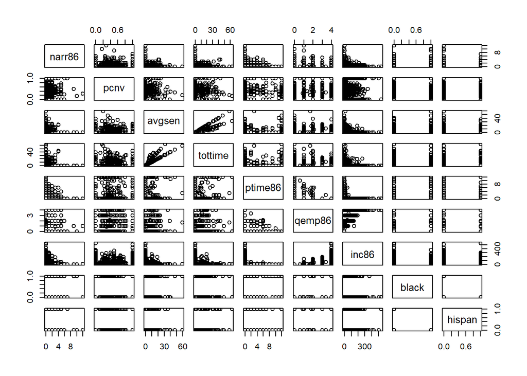

```r
# Carga de base de datos
data(crime1)

# Seleccion de variables relevantes
base1 <- crime1 %>%
  select(narr86, pcnv, avgsen, tottime, ptime86,
         qemp86, inc86, black, hispan)

# Grafica base
plot(base1)
```

```r
# Estimacion del modelo
modelo1 <- lm(formula = narr86 ~ pcnv + avgsen + tottime + ptime86 +
                qemp86 + inc86 + black + hispan,
              data = base1)

# Presentacion de resultados
stargazer(modelo1, digits = 3,
          type = "text", style = "io",
          dep.var.labels = c("Arrestos"),
          covariate.labels = c("% Encarcelamientos", "Duración Sentencia",
                               "Tiempo Total en Prisión",
                               "Tiempo en Prisión en 86",
                               "Trimestres con Empleo", "Ingresos",
                               "Afrodescendiente", "Hispano",
                               "Constante"))
```

```
##
## ------------------------------------------------------
##                                    Arrestos
## ------------------------------------------------------
## % Encarcelamientos                -0.133***
##                                    (0.040)
## Duración Sentencia                  -0.011
##                                    (0.012)
## Tiempo Total en Prisión             0.012
##                                    (0.009)
## Tiempo en Prisión en 86           -0.041***
##                                    (0.009)
## Trimestres con Empleo             -0.051***
##                                    (0.014)
## Ingresos                          -0.001***
##                                    (0.0003)
## Afrodescendiente                   0.327***
##                                    (0.045)
## Hispano                            0.194***
##                                    (0.040)
## Constante                          0.569***
##                                    (0.036)
## Observations                        2,725
## R-squared                           0.072
## Adjusted R-squared                  0.070
## Residual standard error       0.829 (df = 2716)
## F statistic                26.467*** (df = 8; 2716)
## ------------------------------------------------------
## Notes:                  ***p < .01; **p < .05; *p < .1
```

Por ahora, de los resultados obtenidos, sólo nos interesa destacar que la gran mayoría de las variables explicativas usadas son significativas.

Pese a esto, vale la pena preguntarse si de verdad se está describiendo adecuadamente el fenómeno económico que se quiere explicar. En particular nos preguntamos ¿es posible que alguna de nuestras variables explicativas tenga una relación no lineal con la variable dependiente?

Para explorar esta posibilidad, estimaremos un nuevo modelo que incluirá todas las variables significativas del modelo original, así como los términos cuadráticos de las variables explicativas (significativas) en las tenga sentido.

```r
# Estimacion del modelo
modelo2 <- lm(formula = narr86 ~ pcnv + I(pcnv^2) +
                                 avgsen +
                                 tottime +
                                 ptime86 + I(ptime86^2) +
                                 qemp86 +
                                 inc86 + I(inc86^2) +
                                 black + hispan,
              data = base1)

# Presentacion de resultados
stargazer(modelo1, modelo2, digits = 3,
          type = "text", style = "io",
          dep.var.labels = c("Arrestos"),
          covariate.labels = c("% Encarcelamientos", "% Encarcelamientos-SQ",
                               "Duración Sentencia",
                               "Tiempo Total en Prisión",
                               "Tiempo en Prisión en 86", "Tiempo en Prisión en 86-SQ",
                               "Trimestres con Empleo",
                               "Ingresos", "Ingresos-SQ",
                               "Afrodescendiente", "Hispano",
                               "Constante"))
```

```
##
## -----------------------------------------------------------------------------
##                                                 Arrestos
##                                      (1)                       (2)
## -----------------------------------------------------------------------------
## % Encarcelamientos                -0.133***                 0.553***
##                                    (0.040)                   (0.154)
## % Encarcelamientos-SQ                                       -0.730***
##                                                              (0.156)
## Duración Sentencia                  -0.011                   -0.017
##                                    (0.012)                   (0.012)
## Tiempo Total en Prisión             0.012                     0.012
##                                    (0.009)                   (0.009)
## Tiempo en Prisión en 86           -0.041***                 0.287***
##                                    (0.009)                   (0.044)
## Tiempo en Prisión en 86-SQ                                  -0.030***
##                                                              (0.004)
## Trimestres con Empleo             -0.051***                  -0.014
##                                    (0.014)                   (0.017)
## Ingresos                          -0.001***                 -0.003***
##                                    (0.0003)                  (0.001)
## Ingresos-SQ                                                0.00001***
##                                                             (0.00000)
## Afrodescendiente                   0.327***                 0.292***
##                                    (0.045)                   (0.045)
## Hispano                            0.194***                 0.164***
##                                    (0.040)                   (0.039)
## Constante                          0.569***                 0.505***
##                                    (0.036)                   (0.037)
## Observations                        2,725                     2,725
## R-squared                           0.072                     0.103
## Adjusted R-squared                  0.070                     0.100
## Residual standard error       0.829 (df = 2716)         0.815 (df = 2713)
## F statistic                26.467*** (df = 8; 2716) 28.460*** (df = 11; 2713)
## -----------------------------------------------------------------------------
## Notes:                     ***p < .01; **p < .05; *p < .1
```

Los resultados obtenidos muestran que, en lo individual, los términos cuadráticos que se añadieron son significativos. Sin embargo, para validar que deban incluirse en el modelo debemos realizar la prueba $F$ correspondiente:

```r
# Prueba F
linearHypothesis(modelo2,
                 c("I(pcnv^2) = 0",
                   "I(ptime86^2) = 0",
                   "I(inc86^2) = 0"))
```

```
## Linear hypothesis test
##
## Hypothesis:
## I(pcnv^2) = 0
## I(ptime86^2) = 0
## I(inc86^2) = 0
##
## Model 1: restricted model
## Model 2: narr86 ~ pcnv + I(pcnv^2) + avgsen + tottime + ptime86 + I(ptime86^2) +
##     qemp86 + inc86 + I(inc86^2) + black + hispan
##
##   Res.Df    RSS Df Sum of Sq      F    Pr(>F)
## 1   2716 1865.0
## 2   2713 1802.4  3    62.589 31.404 < 2.2e-16 ***
## ---
## Signif. codes:  0 '***' 0.001 '**' 0.01 '*' 0.05 '.' 0.1 ' ' 1
```

Los resultados de la prueba indican que se debe rechazar la hipótesis nula. Esto indica que los términos cuadráticos son relevantes para explicar el fenómeno económico en cuestión. Por tanto, tenemos evidencia de que el modelo original no contemplaba algunas relaciones no lineales importantes entre las variables explicativas y la variable explicada.

Ahora, si bien la inclusión de los términos cuadráticos complica un poco la interpretación del modelo, esto nos revela algunos detalles importantes del fenómeno del crimen. Por ejemplo para la variable `pcnv` que puede ser interpretada como la “probabilidad de ser encarcelado una vez que se ha detenido a una persona” tenemos:

- En el modelo original, si la probabilidad de encarcelamiento incrementa en 7.506pp, entonces el número de arrestos disminuye en 1 (en promedio).
- En el modelo con términos cuadráticos se identifica un efecto marginal decreciente.  
  En particular tenemos que el punto de inflexión en la relación entre `pcnv` y `narr96` se da cuando `pcnv` $=$ 0.378. Esto quiere decir que en este modelo, la probabilidad de ser encarcelado no desincentiva el crimen sino hasta niveles relativamente altos de `pcnv`.

¿Cuál de las dos historias es la “correcta”?

### 10.4.2. Prueba RESET

Construyamos un modelo para determinar el precio de una casa. Para este modelo se considerarán como variables explicativas:

- `lotsize`: tamaño del lote.
- `sqrft`: tamaño de la construcción.
- `bdrms`: número de cuartos en la casa.

Sobre algunas variables explicativas tenemos la duda de si usar su versión de nivel o su versión de logaritmo. Ante esta duda, se decide estimar ambos modelos:

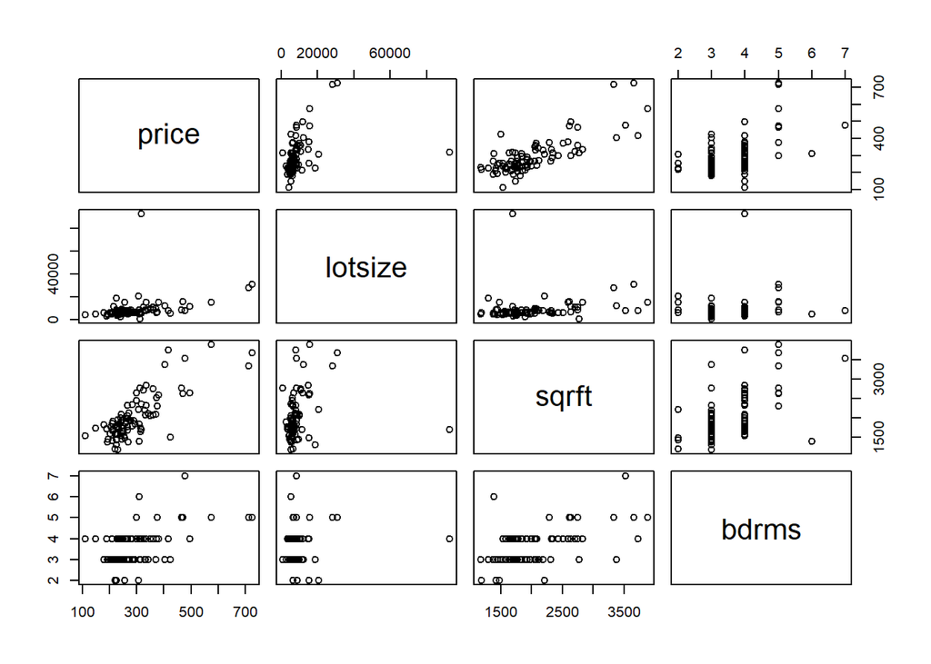

```r
# Carga de la base de datos
data(hprice1)

# Seleccion de variables de interes
base2 <- hprice1 %>%
  select(price, lotsize, sqrft, bdrms)

# Grafica base

plot(base2)
```

```r
# Estimacion modelo de niveles
casas_nvl <- lm(price ~ lotsize + sqrft + bdrms,
                data = base2)

# Estimacion modelo de logaritmos
casas_log <- lm(log(price) ~ log(lotsize) +log(sqrft) + bdrms,
                data = base2)

# Presentamos los resultados
stargazer(casas_nvl, casas_log, dsigits = 3,
          type = "text", style = "io",
          dep.var.labels = c("Precio", "LOG(Precio)"),
          covariate.labels = c("Lote", "Construcción",
                               "LOG(Lote)", "LOG(Construcción)",
                               "Cuartos", "Constante"))
```

```
##
## -----------------------------------------------------------------
##                                       Precio        LOG(Precio)
##                                         (1)             (2)
## -----------------------------------------------------------------
## Lote                                 0.002***
##                                       (0.001)
## Construcción                         0.123***
##                                       (0.013)
## LOG(Lote)                                            0.168***
##                                                       (0.038)
## LOG(Construcción)                                    0.700***
##                                                       (0.093)
## Cuartos                               13.853           0.037
##                                       (9.010)         (0.028)
## Constante                             -21.770        -1.297**
##                                      (29.475)         (0.651)
## Observations                            88              88
## R-squared                              0.672           0.643
## Adjusted R-squared                     0.661           0.630
## Residual standard error (df = 84)     59.833           0.185
## F statistic (df = 3; 84)             57.460***       50.424***
## -----------------------------------------------------------------
## Notes:                            ***p < .01; **p < .05; *p < .1
##
## -
## 3
## -
```

A priori, nada en los resultados obtenidos nos indica que un modelo sea mejor que otro. Salvo que tengamos evidencia de que alguno tiene problemas de especificación, podríamos usar cualquiera de los dos para explicar el fenómeno económico de interés.

Para verificar si alguno de los dos modelos sufre de errores de especificación (y poder decidir cuál modelo es mejor), procedemos a realizar la prueba RESET. Para hacerlo,realizaremos una regresión auxiliar que incorpora los valores ajustados (cuadrados y cúbicos) de la regresión original.

Los resultados de la regresión original no son de interés para nosotros. Lo que nos interesa el es estadístico $F$ de la prueba de significancia conjunta de los coeficientes de los valores ajustados que se agregaron enm la regresión auxiliar:

```r
# Modelo auxiliar niveles
aux_nvl <- lm(price ~ lotsize + sqrft + bdrms +
                I(fitted(casas_nvl)^2) + I(fitted(casas_nvl)^3),
              data = base2)

# Modelo auxiliar logaritmos
aux_log <- lm(log(price) ~ log(lotsize) +log(sqrft) + bdrms +
                I(fitted(casas_log)^2) + I(fitted(casas_log)^3),
              data = base2)

# RESET para el modelo de niveles
linearHypothesis(aux_nvl,
                 c("I(fitted(casas_nvl)^2) = 0",
                   "I(fitted(casas_nvl)^3) = 0"))
```

```
## Linear hypothesis test
##
## Hypothesis:
## I(fitted(casas_nvl)^2) = 0
## I(fitted(casas_nvl)^3) = 0
##
## Model 1: restricted model
## Model 2: price ~ lotsize + sqrft + bdrms + I(fitted(casas_nvl)^2) + I(fitted(casas_nvl)^3)
##
##   Res.Df    RSS Df Sum of Sq      F  Pr(>F)
## 1     84 300724
## 2     82 269984  2     30740 4.6682 0.01202 *
## ---
## Signif. codes:  0 '***' 0.001 '**' 0.01 '*' 0.05 '.' 0.1 ' ' 1
```

```r
# RESET para el modelo de logaritmos
linearHypothesis(aux_log,
                 c("I(fitted(casas_log)^2) = 0",
                   "I(fitted(casas_log)^3) = 0"))
```

```
## Linear hypothesis test
##
## Hypothesis:
## I(fitted(casas_log)^2) = 0
## I(fitted(casas_log)^3) = 0
##
## Model 1: restricted model
## Model 2: log(price) ~ log(lotsize) + log(sqrft) + bdrms + I(fitted(casas_log)^2) +
##     I(fitted(casas_log)^3)
##
##   Res.Df    RSS Df Sum of Sq     F  Pr(>F)
## 1     84 2.8626
## 2     82 2.6940  2   0.16854 2.565 0.08308 .
## ---
## Signif. codes:  0 '***' 0.001 '**' 0.01 '*' 0.05 '.' 0.1 ' ' 1
```

Para el modelo de niveles, el valor-$p$ de la prueba nos lleva a rechazar (al 5% de significancia) la hipótesis nula. En la prueba RESET es importante recordar que la hipótesis nula es que el modelo propuesto no tiene error de especificación. Por tanto, el resultado obtenido es evidencia de que el modelo de niveles tiene error de especificación.

De manera análoga, el valor-$p$ de la prueba realizada al modelo de logaritmos nos lleva a no rechazar la hipótesis nula (al 5% de significancia), por lo que podemos concluir que este modelo no tiene error de especificación y, por tanto, es preferido al modelo de niveles.

### 10.4.3. Pruebas para Modelos no Anidados

Retomemos el ejemplo anterior pero desde una perspectiva diferente. Supongamos que ya sabemos que el modelo debe usar la variable dependiente en su forma logarítmica, pero no tenemos claro si las variables explicativas deben en su versión de nivel o de logaritmos. La prueba Davidson-MacKinnon nos puede ayudar a resolver este problema.

Primero debemos estimar ambas propuestas de modelo:

```r
# Estimacion modelo niveles
mod_nvl <- lm(log(price) ~ lotsize + sqrft + bdrms,
              data = base2)

# Estimacion modelo logaritmos
mod_log <- lm(log(price) ~ log(lotsize) +log(sqrft) + bdrms,
              data = base2)

# Presentacion de los resultados
stargazer(mod_nvl, mod_log, digits = 3,
          type = "text", style = "io",
          dep.var.labels = c("LOG(Precio)"),
          column.labels = c("Niveles", "Logaritmos"),
          covariate.labels = c("Lote", "Construcción",
                               "LOG(Lote)", "LOG(Construcción)",
                               "Cuartos", "Constante"))
```

```
##
## -----------------------------------------------------------------
##                                             LOG(Precio)
##                                       Niveles       Logaritmos
##                                         (1)             (2)
## -----------------------------------------------------------------
## Lote                                0.00001***
##                                      (0.00000)
## Construcción                         0.0004***
##                                      (0.00004)
## LOG(Lote)                                            0.168***
##                                                       (0.038)
## LOG(Construcción)                                    0.700***
##                                                       (0.093)
## Cuartos                                0.025           0.037
##                                       (0.029)         (0.028)
## Constante                            4.759***        -1.297**
##                                       (0.094)         (0.651)
## Observations                            88              88
## R-squared                              0.622           0.643
## Adjusted R-squared                     0.609           0.630
## Residual standard error (df = 84)      0.190           0.185
## F statistic (df = 3; 84)             46.128***       50.424***
## -----------------------------------------------------------------
## Notes:                            ***p < .01; **p < .05; *p < .1
```

La prueba DM consiste en una simple prueba $t$ (de dos colas) sobre el coeficiente de una regresión ampliada.

Si suponemos que el modelo correcto es el modelo en si versión de niveles, entonces agregar los valores ajustados de la regresión de logaritmos no debería resultar en un coeficiente significativo. De manera análoga, si suponemos que el modelo de logaritmos es correcto, entonces agregar los valores ajustados de la regresión de niveles no debería resultar en un coeficiente significativo.

```r
# Modelo niveles ampliado
mod_nvl_amp <- lm(log(price) ~ lotsize + sqrft + bdrms +
                    fitted(mod_log),
                  data = base2)

# Modelo logaritmos ampliado
mod_log_amp <- lm(log(price) ~ log(lotsize) +log(sqrft) + bdrms +
                    fitted(mod_nvl),
                  data = base2)
```

De los modelos ampliados no nos interesan los coeficientes estimados. Sólo nos interesa la significancia estadística (valor-$p$ de la prueba $t$) de los coeficientes asociados a los valores ajustados que se agregaron:

- Para el modelo de niveles tenemos que el coeficiente estimado de los valores ajustados (del modelo de logaritmos) es 0.828 y su error estándar es 0.353. Esto resulta en un estadístico $t$ de 2.343 y un valor-$p$ de la prueba de 0.0215. Esto nos lleva a rechazar la hipótesis nula de la prueba DM (con una significancia del 5%) y, por tanto, tenemos evidencia de que el modelo de niveles sufre de error de especificación.
- Para el modelo de logaritmos tenemos que el coeficiente estimado de los valores ajustados (del modelo de viveles) es 0.332 y su error estándar es 0.432. Esto resulta en un estadístico $t$ de 0.769 y un valor-$p$ de la prueba de 0.444. Esto nos lleva a no rechazar la hipótesis nula de la prueba DM y, por tanto, tenemos evidencia de que el modelo de logaritmos no sufre de error de especificación.

Otra alternativa para ver cual de los dos modelos es más adecuado es crear un modelo que contenga ambas propuestas (niveles y logaritmos) como casos particulares y después hacer una prueba $F$ sobre los coeficientes asociados a las variables de nivel y de logaritmos:

```r
# Modelo extendido
mod_ext<- lm(log(price) ~ lotsize + sqrft + bdrms + log(lotsize) + log(sqrft),
             data = base2)

# Prueba para verificar el modelo de niveles
linearHypothesis(mod_ext,
                 c("log(lotsize) = 0", "log(sqrft) = 0"))
```

```
## Linear hypothesis test
##
## Hypothesis:
## log(lotsize) = 0
## log(sqrft) = 0
##
## Model 1: restricted model
## Model 2: log(price) ~ lotsize + sqrft + bdrms + log(lotsize) + log(sqrft)
##
##   Res.Df    RSS Df Sum of Sq      F  Pr(>F)
## 1     84 3.0284
## 2     82 2.7325  2   0.29594 4.4404 0.01476 *
## ---
## Signif. codes:  0 '***' 0.001 '**' 0.01 '*' 0.05 '.' 0.1 ' ' 1
```

```r
# Prueba para verificar el modelo de logaritmos
linearHypothesis(mod_ext,
                 c("lotsize = 0", "sqrft = 0"))
```

```
## Linear hypothesis test
##
## Hypothesis:
## lotsize = 0
## sqrft = 0
##
## Model 1: restricted model
## Model 2: log(price) ~ lotsize + sqrft + bdrms + log(lotsize) + log(sqrft)
##
##   Res.Df    RSS Df Sum of Sq      F Pr(>F)
## 1     84 2.8626
## 2     82 2.7325  2   0.13007 1.9516 0.1486
```

Los resultados indican:

- Si suponemos que el modelo de niveles es correcto, encontramos que las variables en su versión de logaritmos son significativas pues el resultado de la prueba $F$ tiene un valor-P de 0.015, que nos lleva a rechazar la hipótesis nula de la prueba.
- Si suponemos que el modelo de logaritmos es correcto, encontramos que las variables en su versión de niveles no son significativas pues el resultado de la prueba $F$ tiene un valor-P de 0.149, que nos lleva a no rechazar la hipótesis nula de la prueba.

### 10.4.4. Usando Variables Proxy

Consideremos un modelo para explicar el salario (logarítmico) de los trabajadores. Para esto, usaremos como variables explicativas a:

- `educ`: años de escolaridad.
- `exper`: años de experiencia laboral.
- `tenure`:antigüedad en el trabajo actual.
- `married`: dummy de casado.
- `south`: dummy de si vive en el sur
- `urban`: dummy de zona urbana.
- `black`: dummy de afrodescendiente

Además de estas variables, creemos que otra variable explicativa relevante es la habilidad (`abil`) que tiene un trabajador. Desafortunadamente, por diversos motivos, no se cuenta con información de esta variable. Sin embargo, se propone la variable `IQ` (cociente intelectual) como proxy de la habilidad.

Estimaremos dos modelos: uno sin y otro con el `IQ` como proxy para analizar los diferentes resultados que se tendrían.

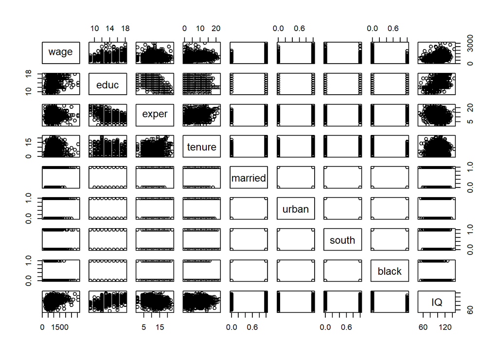

```r
# Carga de datos
data(wage2)

# Seleccion de variables relevantes
base4 <- wage2 %>%
  select(wage, educ, exper, tenure, married,
         urban, south, black, IQ)

# Grafica base
plot(base4)
```

```r
# Estimacion modelo sin IQ
no_proxy<- lm(log(wage) ~ educ + exper + tenure + married +
                urban + south + black,
              data = base4)

# Estimacion el modelo con IQ
si_proxy <- lm(log(wage) ~ educ + exper + tenure + married +
                 urban + south + black + IQ,
               data = base4)

# Presentacion de resultados
stargazer(no_proxy, si_proxy, digits = 3,
          type = "text", style = "io",
          dep.var.labels = c("LOG(Salario)"),
          covariate.labels = c("Educación", "Experiencia", "Antigüedad",
                               "Casado", "Zona Urbana", "Sureño",
                               "Afrodescendiente", "IQ", "Constante"))
```

```
##
## -----------------------------------------------------------------------
##                                          LOG(Salario)
##                                   (1)                     (2)
## -----------------------------------------------------------------------
## Educación                      0.065***                0.054***
##                                 (0.006)                 (0.007)
## Experiencia                    0.014***                0.014***
##                                 (0.003)                 (0.003)
## Antigüedad                     0.012***                0.011***
##                                 (0.002)                 (0.002)
## Casado                         0.199***                0.200***
##                                 (0.039)                 (0.039)
## Zona Urbana                    0.184***                0.182***
##                                 (0.027)                 (0.027)
## Sureño                         -0.091***               -0.080***
##                                 (0.026)                 (0.026)
## Afrodescendiente               -0.188***               -0.143***
##                                 (0.038)                 (0.039)
## IQ                                                     0.004***
##                                                         (0.001)
## Constante                      5.395***                5.176***
##                                 (0.113)                 (0.128)
## Observations                      935                     935
## R-squared                        0.253                   0.263
## Adjusted R-squared               0.247                   0.256
## Residual standard error    0.365 (df = 927)        0.363 (df = 926)
## F statistic             44.747*** (df = 7; 927) 41.265*** (df = 8; 926)
## -----------------------------------------------------------------------
## Notes:                  ***p < .01; **p < .05; *p < .1
```

En el modelo sin el proxy observamos que un año adicional de educación se traduce en un salario 6.543% mayor, lo que representa un retorno a la educación considerable. Sin embargo, dado que creemos que la variable `abil` tiene un efecto sobre el salario, este coeficiente sufre de sesgo de variable omitida. De hecho, dado que `abil` y `educ` seguramente tienen una correlación positiva, el efecto antes descrito está sobre-estimado.

Esto se verifica en el modelo que usa el `IQ` como proxy de `abil`. En este caso, un año adicional de educación se traduce en un salario 5.441% mayor, lo que sigue representando un retorno a la educación considerable (aunque menor que en el modelo sin proxy). Además podemos observar que el propio `IQ` tiene un efecto positivo y estadísticamente significativo sobre el salario.

# 10.5. Ejercicios

1. Considere la base de datos `ceosal2` para estimar el modelo
   $$\ln(salary) = \beta_0 + \beta_1 \:
   \ln(sales) + \beta_2 \: \ln(mktval) + \beta_3 \: profmarg + \beta_4 \:
   ceoten + \beta_5 \: comten + u$$
   1. Estime el modelo especificado así como el modelo que incluye los términos cuadráticos de `ceoten` y `comten`. Presente los resultados en una tabla de `stargazer`.
   2. ¿Hay evidencia de error de especificación en los modelos estimados?
2. Considere la base de datos en `ceosal1` para estimar el modelo
   $$\ln(salary) = \beta_0 + \beta_1 \:
   \ln(sales) + \beta_2 \: roe + \beta_3 \: rosneg + u$$
   donde `rosneg` es una variable dummy que toma el valor de 1 cuando $ros < 0$ y 0 en otro caso.
   1. Usando la prueba RESET concluya si este modelo sufre de error de especificación.
   2. Si el modelo sufre de error de especificación, proponga un nuevo modelo que no tenga ese problema.